# 8. Investigate Driver Mutations

Will Hannon

28 April, 2023

The goal of this notebook is to determine how subclonal ‘driver’ mutations fit on the tree.

```r
## ==== File paths input data ==== ##

if (exists("snakemake")) {

  # Data from lofreq and varscan labeled with subclonal haplotypes
  updated.data = snakemake@params[["incsv"]]

  # Original unfiltered variant calls
  variant.data = snakemake@params[["rawvariants"]]

  # Data from the count of bridging reads
  bridging.data = snakemake@input[[1]]

  # Data from Iris' driver mutations
  driver.mutations = snakemake@params[["drivers"]]

  # Annotations for MeV genes
  annotations.filepath = snakemake@params[["annotations"]]

} else {

  # Data from lofreq and varscan labeled with subclonal haplotypes
  updated.data = "../../results/variants/validated_variants.csv"

  # Original unfiltered variant calls
  variant.data = "../../results/variants/variants.csv"

  # Data from the count of bridging reads
  bridging.data = "../../results/bridging/bridging_reads.csv"

  # Data from Iris' driver mutations
  driver.mutations = "../../config/driver_mutations.csv"

  # Annotations for MeV genes
  annotations.filepath = "../../config/annotations.csv"

}
```

```r
## ==== File paths output data ==== ##

if (exists("snakemake")) {

  # Path to save figures
  figure.dir = paste0(snakemake@params[['figures']], "/")

} else {

  # Path to save figures
  figure.dir = "../../results/figures/"

}

# Make the figure directory if it doesn't exist
if (!file.exists(figure.dir)) {
  dir.create(figure.dir, recursive = TRUE)
  print("Directory created.")
} else {
  print("Directory already exists.")
}
```

```
## [1] "Directory already exists."
```

Lets load in the data from Iris. In total, there are 13 possible driver mutations. However, some of these are fixed on the ‘ancestor’ or reference. If we exclude these, there are only 9 drivers that aren’t fixed.

Non-ancestral ‘Drivers’

| SNP | AA_Change | Gene | Haplotype |
| --- | --- | --- | --- |
| T3586C | Phe50Ser | M | genome-1-1 |
| G6775A | Ala440Thr | F | subclonal |
| C7036T | Gln527* | F | both |
| T7293C | Ile8Thr | H | both |
| T7301C | Phe11Leu | H | subclonal |
| T7304C | Tyr12His | H | cluster 6 |
| C6776A | Ala440Glu | F | cluster 12 |
| G7033T | Glu526* | F | subclonal |
| T7302C | Phe11Ser | H | subclonal |

Of these 9 drivers, we’re able to haplotype 3 of them, however, the remaining 6 lack phylogenetic context. Let’s see what these are.

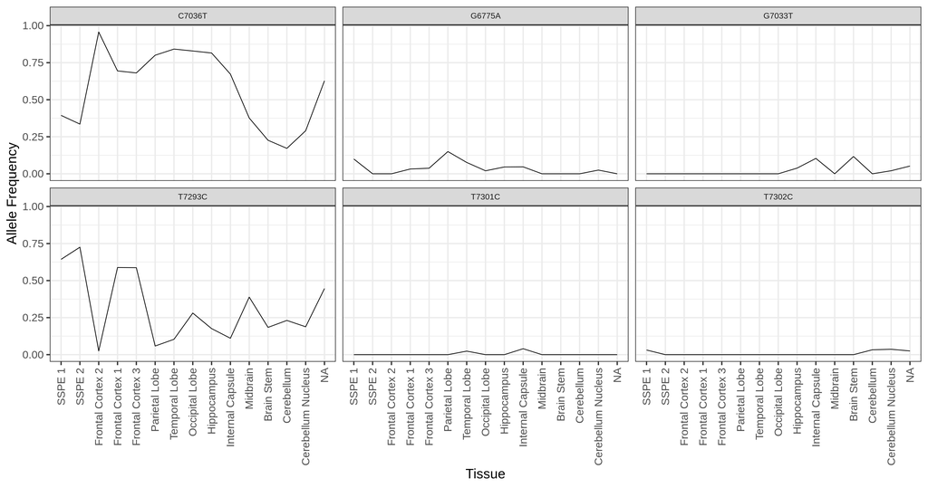

We’ve already know about two of these SNPs - `C7036T` and `T7293C` - that we believe are on both genome-1 and genome-2. Of the remaining four *new* driver SNPs without phylogenetic context, only `G6775A` and `G7033T` are high-enough frequency to reasonable assign to on of the clusters we’ve already determined.

## SNP: G7033T

This is an interesting SNP because, like `C7036T` (shown above), it’s a stop codon in the C-terminal domain of the Fusion protein.

Coding Effect of G7033T

| SNP | AA_Change | Gene |
| --- | --- | --- |
| G7033T | Glu526* | F |

There are three tissues that have this mutation at an appreciable frequency (> 5% Allele Frequency).

Tissues with G7033T

| SNP | AA_Change | Gene | Tissue |
| --- | --- | --- | --- |
| G7033T | Glu526* | F | Upper Brain Stem |
| G7033T | Glu526* | F | Brain Stem |
| G7033T | Glu526* | F | Internal Capsule |

Overall, this SNP is at higher frequency in the lower regions of the brain.

Now, let’s see if there any bridging reads in these tissues that allow us to assign this SNP to an existing cluster. Below, I filtered the bridging read counts for only reads that: 1. Overlap position 7033 (where the driver is) 2. Both SNPs are represented in more than 5% of bridging reads 3. Are only from the three tissues above

Then, I arranged them by the count of reads that contain both SNPs (`11`).

Bridging reads for G7033T

| snp_1 | snp_2 | 00 | 01 | 10 | 11 | Tissue | total |
| --- | --- | --- | --- | --- | --- | --- | --- |
| 7033 | 7036 | 1443 | 4428 | 712 | 1 | Internal Capsule | 6584 |
| 7033 | 7093 | 3602 | 15 | 434 | 1 | Internal Capsule | 4052 |
| 7033 | 7824 | 7 | 1 | 0 | 1 | Internal Capsule | 9 |
| 6945 | 7033 | 2005 | 247 | 7 | 1 | Brain Stem | 2260 |
| 7008 | 7033 | 3950 | 532 | 102 | 1 | Brain Stem | 4585 |
| 7020 | 7033 | 4455 | 600 | 8 | 1 | Brain Stem | 5064 |

What’s really interesting here is that there is strong evidence that this stop codon mutation (`F-526*`) is **not** linked to reads with the other stop codon driver at position `7036` (`F-527*`). This makes sense biologically if these Fusion C-terminal mutants are positively selected.

Reads overlaping 7036

| snp_1 | snp_2 | 00 | 01 | 10 | 11 | Tissue | total |
| --- | --- | --- | --- | --- | --- | --- | --- |
| 7033 | 7036 | 1443 | 4428 | 712 | 1 | Internal Capsule | 6584 |
| 7033 | 7036 | 3502 | 1206 | 649 | 0 | Brain Stem | 5357 |

## SNP: G6775A

`G6775A` is another mutation in Fusion.

Coding Effect of G6775A

| SNP | AA_Change | Gene |
| --- | --- | --- |
| G6775A | Ala440Thr | F |

Can we say anything about this SNP based on bridging reads?

G6775A Bridging Reads

| snp_1 | snp_2 | 00 | 01 | 10 | 11 | Tissue | total |
| --- | --- | --- | --- | --- | --- | --- | --- |
| 6775 | 7036 | 4 | 11 | 0 | 2 | Temporal Lobe | 17 |
| 6775 | 6810 | 4543 | 3 | 518 | 2 | SSPE 1 | 5066 |
| 6775 | 7036 | 42 | 23 | 6 | 2 | SSPE 1 | 73 |
| 6775 | 7036 | 1 | 31 | 8 | 2 | Parietal Lobe | 42 |
| 6764 | 6775 | 5988 | 474 | 20 | 1 | Temporal Lobe | 6483 |
| 6336 | 6775 | 0 | 1 | 5 | 1 | Parietal Lobe | 7 |

Crudely, I’ll try and identify ‘forbidden’ SNPs by taking positions that both have more than 100+ observations of reads where the SNPs aren’t linked.

G6775A Excluded SNPs

| SNP | AA_Change | Gene | AF | Tissue | Haplotype | Background |
| --- | --- | --- | --- | --- | --- | --- |
| G6828A | Leu457Leu | F | 0.1030 | Temporal Lobe | cluster 13 | genome-2 |
| C6712T | His419Tyr | F | 0.0349 | Parietal Lobe | subclonal | subclonal |
| G6828A | Leu457Leu | F | 0.0647 | Parietal Lobe | cluster 13 | genome-2 |
| G6764A | Arg436Lys | F | 0.0382 | SSPE 1 | subclonal | subclonal |

Other than being excluded from cluster 13, it’s not super clear how to fit this mutation onto the phylogeny yet.

## Visualize All Mutations

We looked at all mutations earlier in the analysis. We also looked at putative driver mutations in the context of all mutations. Now we have new cluster names. Let’s re-make these plots.

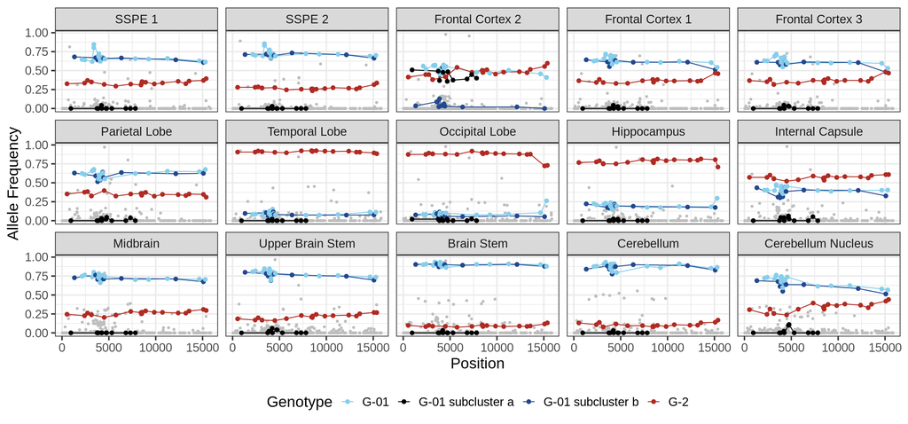